# Quiz 1

박찬영

2024-10-16

Load packages

```r
library(tidyverse)
library(nycflights13)
```

### Problem 1

**Expand the following calls to `count()` to instead use `group_by()`, `summarize()`, and `arrange()`.**

The code for each sub-question must be written in a single pipeline(2 pts each), using pipe operator(%>%).

1. [7점] flights %>% count(dest, sort=TRUE)
2. [7점] flights %>% count(tailnum, wt=distance)

```r
#(a)
flights %>%
    group_by(dest) %>%
    summarise(n=n()) %>%
    arrange(desc(n))
```

```
## # A tibble: 105 × 2
##    dest      n
##    <chr> <int>
##  1 ORD   17283
##  2 ATL   17215
##  3 LAX   16174
##  4 BOS   15508
##  5 MCO   14082
##  6 CLT   14064
##  7 SFO   13331
##  8 FLL   12055
##  9 MIA   11728
## 10 DCA    9705
## # ℹ 95 more rows
```

```r
#(b)
flights %>%
    group_by(tailnum) %>%
    summarise(n=sum(distance))
```

```
## # A tibble: 4,044 × 2
##    tailnum      n
##    <chr>    <dbl>
##  1 D942DN    3418
##  2 N0EGMQ  250866
##  3 N10156  115966
##  4 N102UW   25722
##  5 N103US   24619
##  6 N104UW   25157
##  7 N10575  150194
##  8 N105UW   23618
##  9 N107US   21677
## 10 N108UW   32070
## # ℹ 4,034 more rows
```

### Problem 2

다음의 코드를 실행하여 바람의 돌풍 속도(wind_gust)가 결측인 데이터를 제외하고 주요 변수만을 포함한 결과를 wthr에 저장하시오.

```r
wthr = weather %>%
  filter(!is.na(wind_gust)) %>%
  select(origin, year, month, day, hour, wind_gust)
head(wthr)
```

```
## # A tibble: 6 × 6
##   origin  year month   day  hour wind_gust
##   <chr>  <int> <int> <int> <int>     <dbl>
## 1 EWR     2013     1     1    16      20.7
## 2 EWR     2013     1     1    18      25.3
## 3 EWR     2013     1     1    21      26.5
## 4 EWR     2013     1     1    22      25.3
## 5 EWR     2013     1     2     0      25.3
## 6 EWR     2013     1     2     1      24.2
```

`wthr` **데이터를 이용해, 다음의 조건을 참고하여 아래의 그래프를 재현하시오.**

- [4점] 공항 코드(origin)별 바람의 돌풍 속도(wind_gust)의 box plot을 색을 통해 구분한다.
- [7점] 공항 코드별 이상점은 실제 값에서 랜덤하게 흩뜨려져 표시한다. (단, geom_boxplot(outlier.shape=NA)과 geom_point()를 사용한다.)
- [3점] 그래프의 제목은 ’Boxplot of gust speed’이며, y축 이름은 제거한다.
- [3점] 범례는 그래프의 왼쪽에 위치한다.
- [3점] 배경테마는 black & white (bw)를 사용한다.

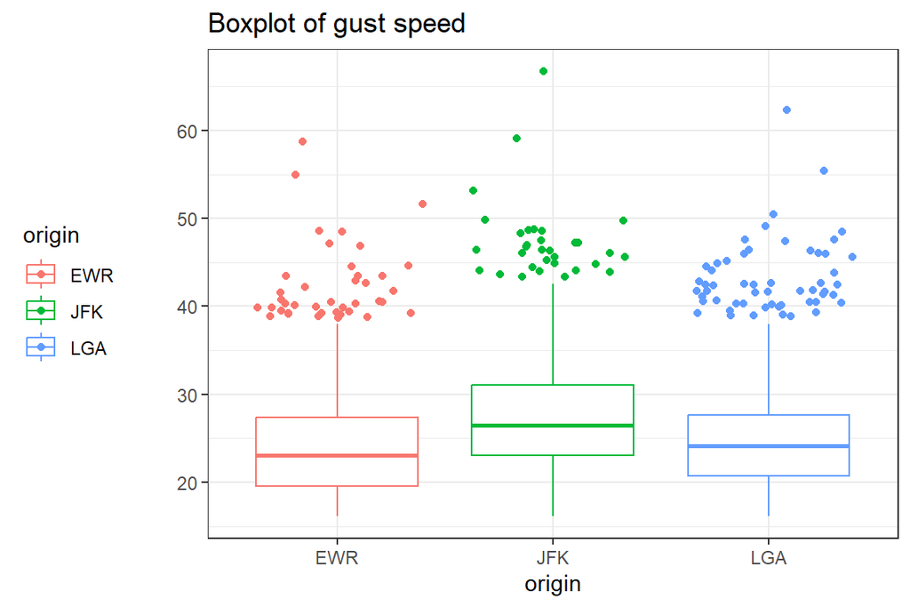

```r
wthr_outlier <- wthr %>%
    group_by(origin) %>%
    mutate(out = quantile(wind_gust)["75%"]+1.5*IQR(wind_gust)) %>%
    filter(wind_gust>out)

ggplot(wthr,aes(origin,wind_gust)) +
geom_boxplot(aes(color=origin),outlier.shape = NA) +
geom_point(data=wthr_outlier,aes(origin,wind_gust,color=origin),position = "jitter") +
labs(title="Boxplot of gust speed",y="") +
theme_bw() +
theme(legend.position = "left")
```

### Problem 3

**다음의 코드를 실행하여 score.csv파일의 데이터를 score 변수에 저장하시오.** (결측치(NA)는 존재하지 않는다.)

```r
score = read_csv('F:\\data\\score.csv')
head(score)
```

```
## # A tibble: 6 × 7
##   id_num group   ev1   ev2   ev3   ev4   ev5
##   <chr>  <chr> <dbl> <dbl> <dbl> <dbl> <dbl>
## 1 T0034  A      71.1  58    45.3  51    80.9
## 2 T0149  B      66.9  42.2  53.8  70.8  85.7
## 3 T0066  A      47.6  53.8  43.6  51.4  62.8
## 4 T0148  C      48    45.6  41.7  48.7  58.7
## 5 T0177  A      83.9  61.9  65.3  69.8  84.6
## 6 T0101  B      56.1  49.5  45.5  52.2  66.2
```

`score.csv`는 프로젝트에 참여한 191명의 대상자에 대한 데이터이며, 각 변수는 다음의 정보를 담고 있다.

- `id_num` : 대상자의 고유 응시번호
- `group` : 대상자가 속한 그룹(A, B, C)
- `ev1 - ev5` : 5명의 심사위원이 부여한 점수

아래 문항에 답하시오. (총 7문항)

1. [3점] **각 그룹에 대해, 그룹에 속한 대상자의 수를 출력하시오.**

```r
score %>% group_by(group) %>% summarise(n=n())
```

```
## # A tibble: 3 × 2
##   group     n
##   <chr> <int>
## 1 A        60
## 2 B        61
## 3 C        70
```

2. [3점] **`summarize()`를 이용하여 첫번째 심사위원 평가(ev1)의 *최고* 득점자와 두번째 심사위원 평가(ev2)의 *최저* 득점자의 응시번호를 출력하시오.** (이 두 항목의 동점자는 존재하지 않는다.)
- 단, `summarize()`를 이용한 single pipeline으로 작성해야 하며(2점), 결과는 아래의 형태로 출력되어야 한다.

| ev1_max | ev2_min |
| --- | --- |
| T0177 | T0043 |

```r
score %>% summarise(
    ev1_max=id_num[rank(ev1)==length(ev1)],
    ev2_min=id_num[rank(ev2)==1]
)
```

```
## # A tibble: 1 × 2
##   ev1_max ev2_min
##   <chr>   <chr>
## 1 T0177   T0043
```

3. [4점] 각 대상자의 최종 점수는 5명의 심사위원이 부여한 점수 중 최저점 1개를 제외한 4개 점수의 평균값으로 사용한다. 모든 대상자의 최종점수를 산출하여 fin 열로 데이터에 추가하시오.
- 최저점이 동점인 경우 1개만 제외하며, 결과를 score_fin으로 저장하고 출력한다.

```r
new_min <- function(v1,v2,v3,v4,v5){
    return(pmap_dbl(list(v1,v2,v3,v4,v5),min))
}

score_fin <- score %>%
    mutate(fin=(ev1+ev2+ev3+ev4+ev5-new_min(ev1,ev2,ev3,ev4,ev5))/4)

score_fin
```

```
## # A tibble: 191 × 8
##    id_num group   ev1   ev2   ev3   ev4   ev5   fin
##    <chr>  <chr> <dbl> <dbl> <dbl> <dbl> <dbl> <dbl>
##  1 T0034  A      71.1  58    45.3  51    80.9  65.2
##  2 T0149  B      66.9  42.2  53.8  70.8  85.7  69.3
##  3 T0066  A      47.6  53.8  43.6  51.4  62.8  53.9
##  4 T0148  C      48    45.6  41.7  48.7  58.7  50.2
##  5 T0177  A      83.9  61.9  65.3  69.8  84.6  75.9
##  6 T0101  B      56.1  49.5  45.5  52.2  66.2  56
##  7 T0104  A      70.9  56.2  36.4  54.4  59    60.1
##  8 T0046  C      44.8  50.5  42    47.4  60    50.7
##  9 T0057  A      61.2  58.5  53.5  59.8  75.3  63.7
## 10 T0013  A      69.7  63.3  57.4  66.1  80.3  69.9
## # ℹ 181 more rows
```

4. [4점] 대상자별 최종점수를 이용해 아래와 같은 히스토그램을 그리시오.
- 단, 다음의 기준을 만족하여야 한다.
  - 그룹별 히스토그램은 색으로 구분되며 별개의 count를 가진다.
  - 구간(bin)의 개수는 25개로 설정한다.
  - 투명도(alpha)는 0.5를 사용한다.

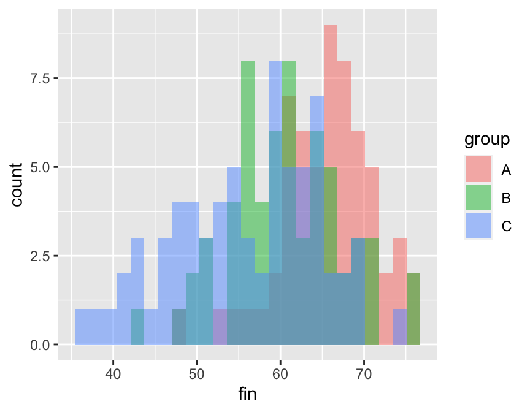

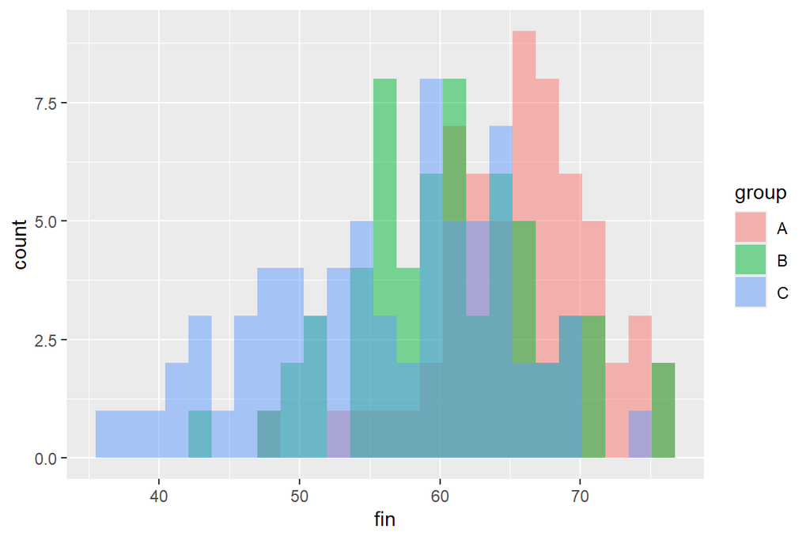

```r
ggplot(score_fin,aes(x=fin)) +
geom_histogram(aes(fill=group), bins = 25, alpha = 0.5,position = "identity")
```

5. [4점]
   $$i$$
   번째 대상자의 최종점수에 대해, 전체 대상자 중에서의 오름차순 순위를 Ri, 속한 그룹 내에서의 오름차순 순위를 Si라고 하자. **모든 대상자에 대해 두 유형의 순위(R과 S)를 계산하여 각각 `ovr_rank`와 `gr_rank` 열로 데이터에 추가하시오.**
- 최종점수가 동점인 경우는 없음을 확인하였으며, 결과를 `score_rank`로 저장하고 출력한다.

```r
score_fin %>% count(fin) %>% filter(n>1) #동점자 없음
```

```
## # A tibble: 0 × 2
## # ℹ 2 variables: fin <dbl>, n <int>
```

```r
score_rank <- score_fin %>%
    mutate(ovr_rank=rank(fin)) %>%
    group_by(group) %>%
    mutate(gr_rank=rank(fin))
```

6. [4점] 아래와 같이 ovr_rank(x축)와 gr_rank(y축)의 산점도와 추세선을 그리시오.
- 단, 다음의 기준을 만족하여야 한다.
  - 그룹별 산점도는 색으로 구분된다.
  - 전체 데이터에 대한 검정색(black) 추세선(smoothing line)이 신뢰구간 음영(band)없이 표시된다.
  - x축과 y축의 이름은 각각 ’Overall Rank’와 ’Group Rank’로 설정한다.

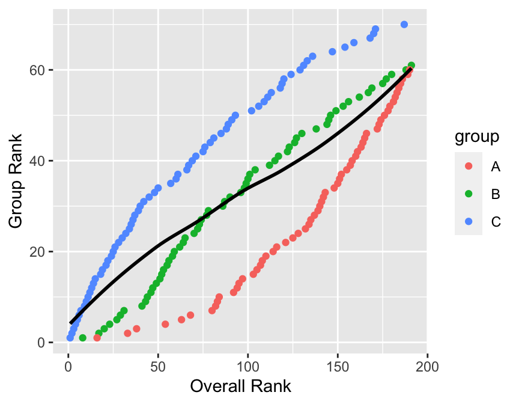

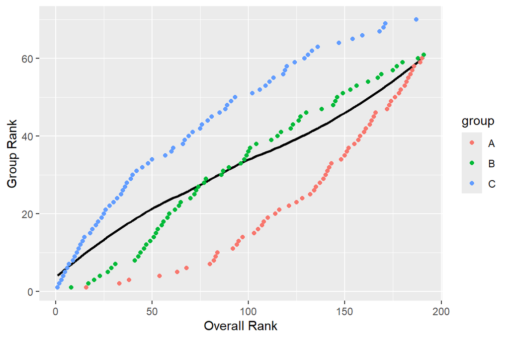

```r
ggplot(score_rank,aes(ovr_rank,gr_rank)) +
geom_smooth(se=FALSE,color="black")+
geom_point(aes(color=group)) +
labs(x="Overall Rank",y="Group Rank")
```

```r
score_rank %>%
    ungroup() %>%
    summarise(
        value=sum((ovr_rank-mean(ovr_rank))*(gr_rank-mean(gr_rank)))/sqrt(sum((ovr_rank-mean(ovr_rank))^2)*sum((gr_rank-mean(gr_rank))^2))
        )
```

```
## # A tibble: 1 × 1
##   value
##   <dbl>
## 1 0.794
```